# Lab/HW 1

Noah Wong

February 5, 2020

## Activity 1:

Do the following tasks: i. Download R ii. Download RStudio iii. Install packages: tidyverse, arules, caret, markdown

## Activity 2:

Perform the following tasks

1. Read the dataset contained in the file ‘artificial_data.csv’ into a data frame.

```r
Artificial.df <- read.csv("artificial_data.csv")
```

2. Plot a histogram of the attribute value. Do it with both base R graphics with ggplot.

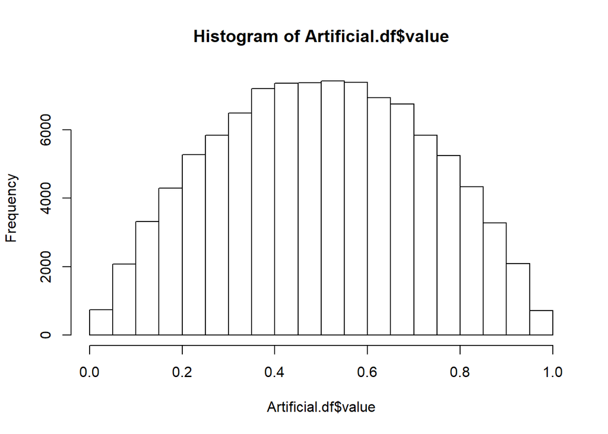

```r
plot1 <- ggplot(Artificial.df, aes(x=value)) +
          geom_histogram(bins = 40)
plot2 <- hist(Artificial.df$value)
```

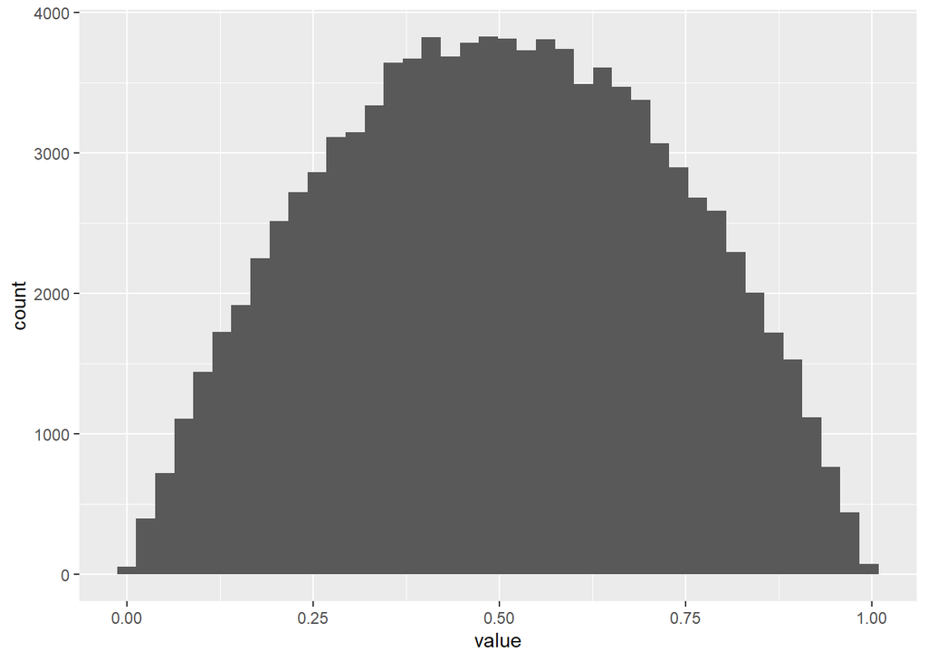

```r
plot1
```

3. Make a function named central which receives as input parameters: a vector v of real values, an integer num_rounds, an integer sample_ size and that does the following

[output not shown]

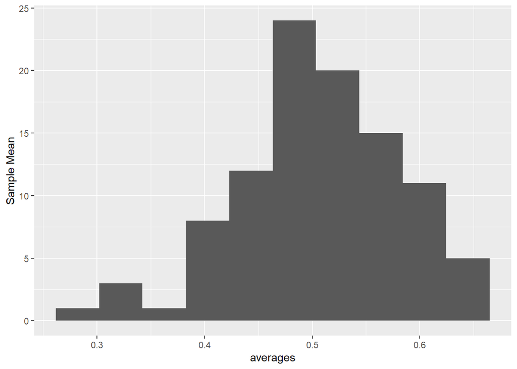

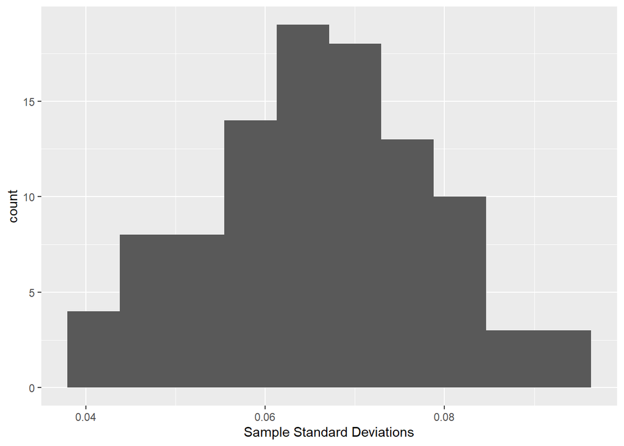

```
##            [,1]
## [1,] 0.50581896
## [2,] 0.06589129
```

```r
central <- function(v, num_rounds, sample_size){
  Tempmatrix = matrix(0, num_rounds, sample_size)
  for(i in 1:num_rounds){
    Tempmatrix[i,] = sample(v,size = sample_size)
  }

  averages = matrix(0,num_rounds, 1)
  for(i in 1:num_rounds) {
    averages[i,] = sum(Tempmatrix[i,])/sample_size
  }

  sdeviations = matrix(0,num_rounds, 1)
  tempsum = 0
  for(i in 1:num_rounds) {
    tempsum = 0
    for(j in 1:sample_size){
      tempsum = tempsum + ((Tempmatrix[i,j] - averages[i,1])^2/(num_rounds-1))
    }
    sdeviations[i,] = sqrt(tempsum)
  }
  plot1 <- ggplot(data.frame(averages), aes(x=averages)) +
           geom_histogram(bins = 10) +
            ylab("Sample Mean")

  print(plot1)

  plot2<- ggplot(data.frame(sdeviations), aes(x=sdeviations)) +
           geom_histogram(bins = 10) +
            xlab("Sample Standard Deviations")

  print(plot2)

  average.and.sdeviation = matrix(0,2,1)
  average.and.sdeviation[1,] = mean(averages)
  average.and.sdeviation[2,] = mean(sdeviations)

  return(average.and.sdeviation)
}
central(Artificial.df$value,100,10)
```

## Activity 4:

Fitting Linear Regression Models a. Find the optimum value for x using the normal equations directly

```r
z = c(3,7,11,18)
H =matrix(c(1,1,1,1,4,6,9,20,8,18,40.5,200),4,3)
ExactAns = solve(t(H)%*% H) %*% (t(H) %*% z)
H
```

[output not shown]

```
##      [,1] [,2]  [,3]
## [1,]    1    4   8.0
## [2,]    1    6  18.0
## [3,]    1    9  40.5
## [4,]    1   20 200.0
```

2. Find the optimum value for x using the lm command in R

```r
df <- data.frame(H)
df$z = z
NoahsFirstModel <- lm(z~X2+X3,data = df)
summary(NoahsFirstModel)
```

```
##
## Call:
## lm(formula = z ~ X2 + X3, data = df)
##
## Residuals:
##         1         2         3         4
## -0.149928  0.285578 -0.145385  0.009736
##
## Coefficients:
##             Estimate Std. Error t value Pr(>|t|)
## (Intercept) -5.44430    0.94291  -5.774   0.1092
## X2           2.39277    0.20224  11.831   0.0537 .
## X3          -0.12210    0.01604  -7.611   0.0832 .
## ---
## Signif. codes:  0 '***' 0.001 '**' 0.01 '*' 0.05 '.' 0.1 ' ' 1
##
## Residual standard error: 0.3539 on 1 degrees of freedom
## Multiple R-squared:  0.999,  Adjusted R-squared:  0.9969
## F-statistic: 489.5 on 2 and 1 DF,  p-value: 0.03195
```

## Activity 6:

Gradient Descent Implementation a. Implement the gradient descent algorithm in R from scratch.

```r
GradientDescent = function(x0, H, z, lambda, epsilon, max_iters) {

  error = 1
  n=0
  x = x0
  errors = matrix(0, max_iters,1)
  while(error > epsilon & n < max_iters ){
    n = n+1
    gradient = t(H)%*%H %*% x - t(H) %*% z

    previous = x
    x = x - lambda*gradient

    error = norm(previous - x, "2")
    errors[n,] = error
  }

  return(c(x,errors))
}
```

2. Run your algorithm on the H and z matrices that we used in class to find x. Choose two different matrices for the initial guess and 3 different values for lamdba, then run your algorithm for all 6 combinations.

```r
initial.guess1 = c(-4,3,1)
initial.guess2 = c(-6, 2,0)
lambda1 = 0.00001
lambda2 = 0.000005
lambda3 = 0.000001
epsilon = 0.0000001
max_iters = 10000
Guess11 = GradientDescent(initial.guess1, H, z, lambda1, epsilon, max_iters)
Guess12 = GradientDescent(initial.guess1, H, z, lambda2, epsilon, max_iters)
Guess13 = GradientDescent(initial.guess1, H, z, lambda3, epsilon, max_iters)
Guess21 = GradientDescent(initial.guess2, H, z, lambda1, epsilon, max_iters)
Guess22 = GradientDescent(initial.guess2, H, z, lambda2, epsilon, max_iters)
Guess23 = GradientDescent(initial.guess2, H, z, lambda3, epsilon, max_iters)
```

3. Make a plot of the log of the difference between concurrent steps as a function of the iteration number i for each combination of values for initial guess and lamdba.

```r
Errors11 = Guess11[4:(max_iters+ 3)]
Errors12 = Guess12[4:(max_iters+3)]
Errors13 = Guess13[4:(max_iters+3)]
Errors21 = Guess21[4:(max_iters+3)]
Errors22 = Guess22[4:(max_iters+3)]
Errors23 = Guess23[4:(max_iters+3)]
```

Creating the Plots

```r
Errors11 = as.data.frame(Errors11)
Errors11$index <- as.numeric(row.names(Errors11))
Errors11$logerror <- log10(Errors11$Errors11)
Plot11 <-  ggplot(data = Errors11,aes(x=index,y=logerror)) +geom_point() +ggtitle("Log Error for lamdba = 0.00001 and initial guess (-4,3,1)")

Errors12 = as.data.frame(Errors12)
Errors12$index <- as.numeric(row.names(Errors12))
Errors12$logerror <- log10(Errors12$Errors12)
Plot12 <-  ggplot(data = Errors12,aes(x=index,y=logerror)) +geom_point() +ggtitle("Log Error for lamdba = 0.000005 and initial guess (-4,3,1)")

Errors13 = as.data.frame(Errors13)
Errors13$index <- as.numeric(row.names(Errors13))
Errors13$logerror <- log10(Errors13$Errors13)
Plot13 <-  ggplot(data = Errors13,aes(x=index,y=logerror)) +geom_point() +ggtitle("Log Error for lamdba = 0.000001 and initial guess (-4,3,1)")

Errors21 = as.data.frame(Errors21)
Errors21$index <- as.numeric(row.names(Errors21))
Errors21$logerror <- log10(Errors21$Errors21)
Plot21 <-  ggplot(data = Errors21,aes(x=index,y=logerror)) +geom_point() +ggtitle("Log Error for lamdba = 0.00001 and initial guess (-6, 2,0)")

Errors22 = as.data.frame(Errors22)
Errors22$index <- as.numeric(row.names(Errors22))
Errors22$logerror <- log10(Errors22$Errors22)
Plot22 <-  ggplot(data = Errors22,aes(x=index,y=logerror)) +geom_point() +ggtitle("Log Error for lamdba = 0.000005 and initial guess (-6, 2,0)")

Errors23 = as.data.frame(Errors23)
Errors23$index <- as.numeric(row.names(Errors23))
Errors23$logerror <- log10(Errors23$Errors23)
Plot23 <-  ggplot(data = Errors23,aes(x=index,y=logerror)) +geom_point() +ggtitle("Log Error for lamdba = 0.000001 and initial guess (-6, 2,0)")
```

Here are my beautiful plots!

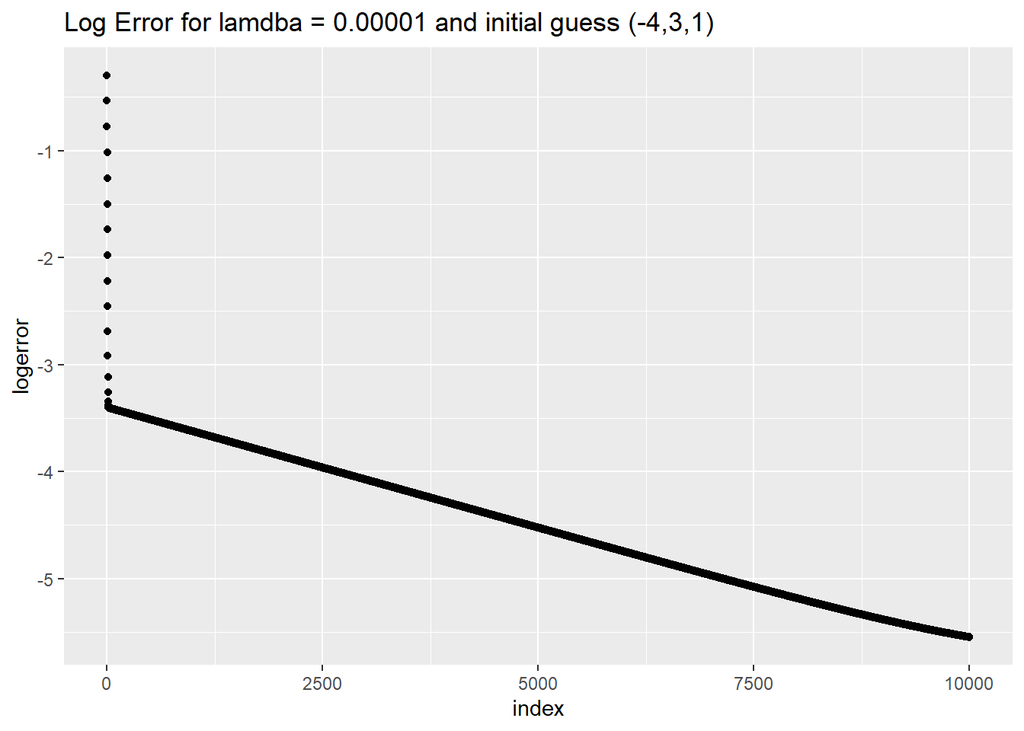

```r
Plot11
```

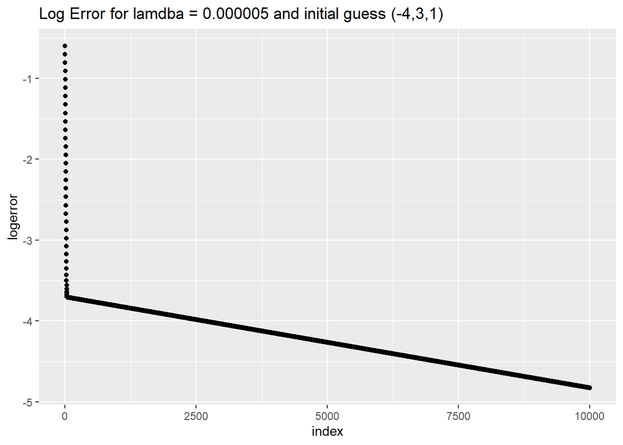

```r
Plot12
```

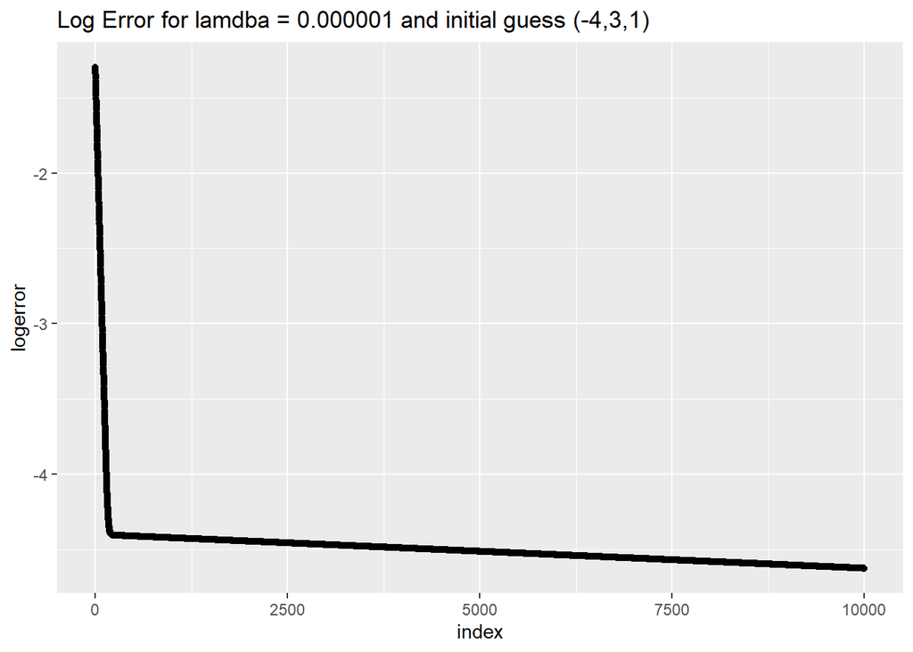

```r
Plot13
```

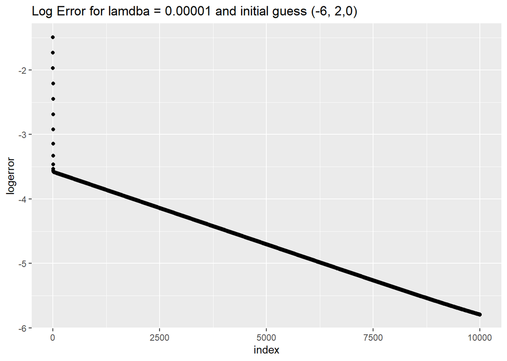

```r
Plot21
```

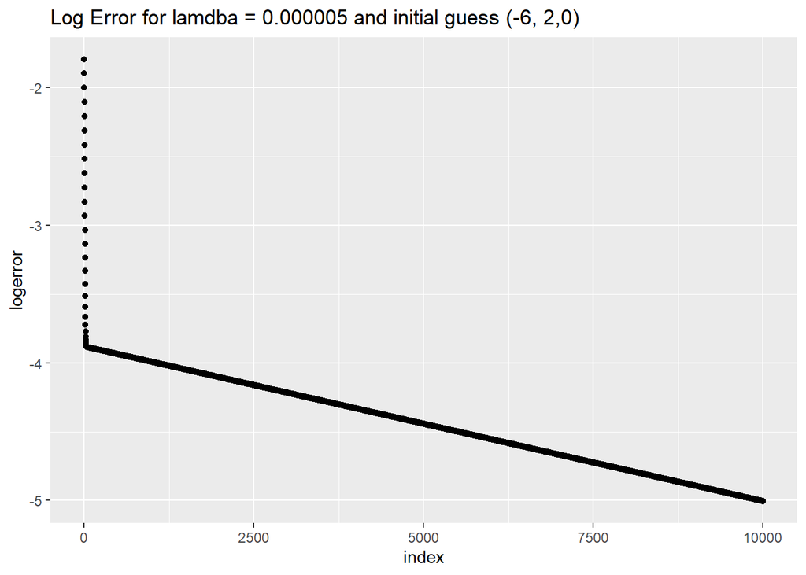

```r
Plot22
```

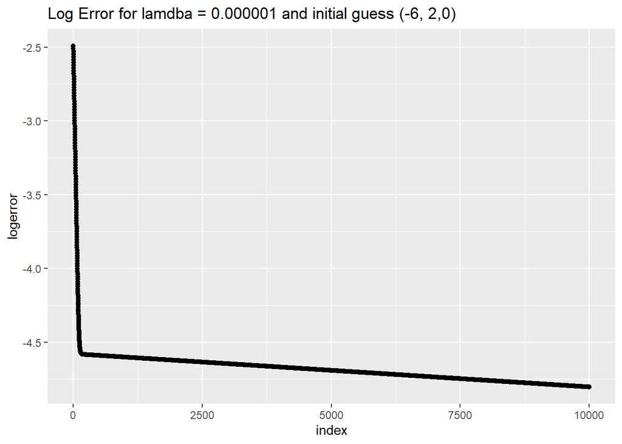

```r
Plot23
```

4. Comment on what you observe in your plots

There appears to be many patterns between the graphs. All of the graphes are decreasing so the log of the error decreases constantly. Also the error gets close to the correct answer very quickly and then after a number of iterations begins to slow considerable. I’ve heard of these graphes being called elbow graphs because they sort of look like an arm with an elbow at the point where the error begins to slow. Also the value with the higher lambda values got closer the error terms got together. Another thing to note is six different lambdas and initial guesses all went to the maximum number of iterations.